# Machine Learning für Journalisten

## Was ist ein Decision Tree / Einführung

Ein Entscheidungsbaum ist ein Baum in dessen Gabelungen Entscheidungsregeln stehen wie z.B. “Ist das Medianeinkommen >= 2452 Euro”. Je nach Antwort geht man nach links oder rechts den Baum weiter bis man in einem Blatt angelangt ist. Im Blatt steht dann die Vorhersage “AfD >= 5%” oder “AfD < 5%”.

Das könnte zum Beispiel so aussehen:

```r
d$factor_party <- factor(with(d,ifelse((AfD <= 5), "AfD <= 5%", "AfD > 5%")))
d = d[,35:45]
d
```

| Wahlbeteiligung | ost_west | Medianeinkommen | Arbeitslosenquote | Ausländeranteil | Schulabgänger.ohne.Abschluss | Kriminalität | Mietpreis | Mietsteigerung | Ländlichkeit | factor_party |
| --- | --- | --- | --- | --- | --- | --- | --- | --- | --- | --- |
| 66.59035 | West | 2867 | 10.5 | 7.9 | 6.1 | 12785 | 6.58 | 19.4 | 0.0 | AfD <= 5% |
| 70.44232 | West | 3129 | 10.1 | 8.7 | 7.8 | 10725 | 7.35 | 15.6 | 0.0 | AfD <= 5% |
| 67.75840 | West | 2885 | 10.1 | 7.6 | 11.5 | 10671 | 7.37 | 13.2 | 0.0 | AfD <= 5% |
| 65.40142 | West | 2699 | 10.9 | 7.1 | 6.1 | 22449 | 6.01 | 15.6 | 0.0 | AfD <= 5% |
| 69.43834 | West | 2749 | 7.4 | 3.5 | 11.3 | 5536 | 5.62 | 10.3 | 74.4 | AfD <= 5% |
| 74.61903 | West | 2676 | 6.0 | 5.2 | 7.8 | 5566 | 6.93 | 17.7 | 36.6 | AfD > 5% |
| 71.14756 | West | 2619 | 6.4 | 4.3 | 7.6 | 5510 | 6.17 | 5.8 | 76.5 | AfD <= 5% |
| 72.97737 | West | 2480 | 6.4 | 3.6 | 8.3 | 6828 | 6.93 | 13.3 | 33.3 | AfD > 5% |
| 75.99635 | West | 2864 | 5.4 | 7.6 | 5.8 | 6504 | 8.35 | 11.0 | 9.6 | AfD <= 5% |
| 77.04602 | West | 2610 | 5.7 | 2.7 | 8.4 | 4611 | 6.42 | 9.3 | 38.8 | AfD <= 5% |

[output cut: 392 more lines]

### Aufteilung der Trainingsdaten

Aber wie funktioniert das Training eines solchen Baumes? Wählen wir ein Attribut aus den Daten, z.B. das Medianeinkommen, können wir dieses gegen die Zielvariable plotten. Nun können wir einen Wert festlegen und immer wenn das Medianeinkommen kleiner ist “AfD > 5%” vorhersagen und sonst “AfD >= 5%”.

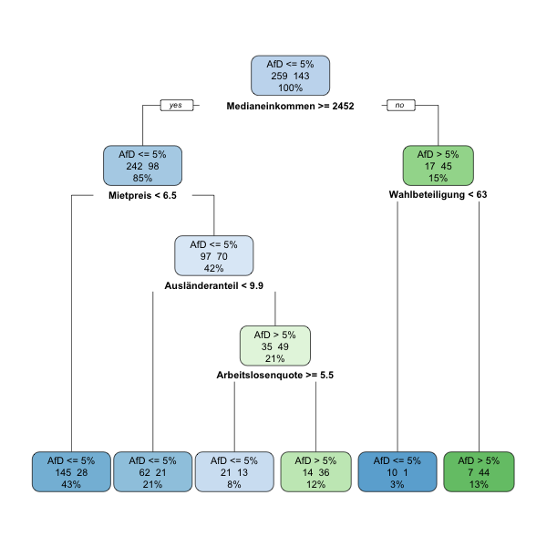

```r
knitr::include_graphics('tree.png')
```

Aber wie finden wir den geeigneten Wert für den “Split”? Dafür können wir einfach alle Werte ausprobieren und die Genauigkeit (Accuracy) des resultierenden Modells betrachten. Die folgende Animation stellt dies dar:

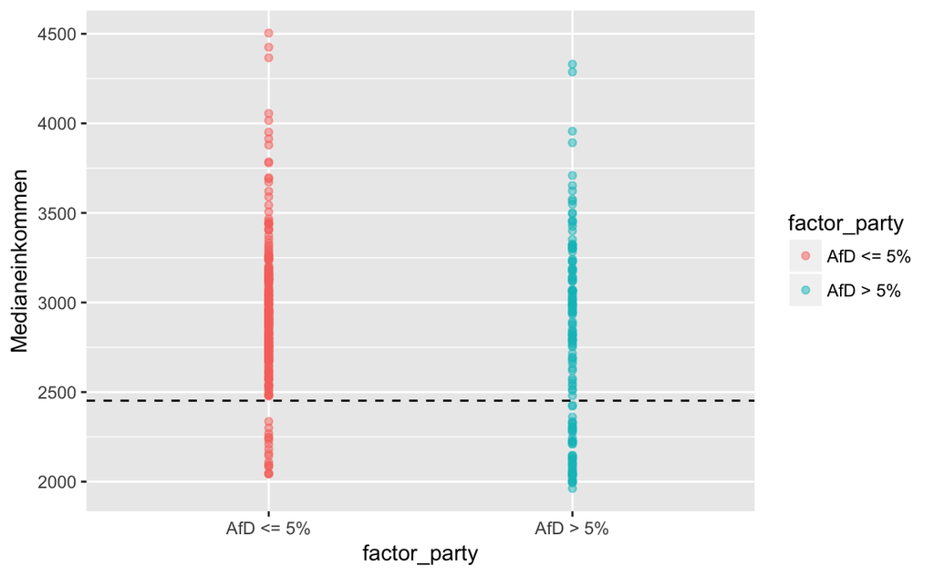

```r
d %>% ggplot() +
  geom_point(aes(factor_party, Medianeinkommen, color=factor_party), alpha = 0.5) +
  geom_hline(yintercept = 2452, linetype = 2)
```

Stattdessen können wir uns auch einen Plot “Split bei Medianeinkommen x” gegen die Genauigkeit des resultierenden Modells anssehen.

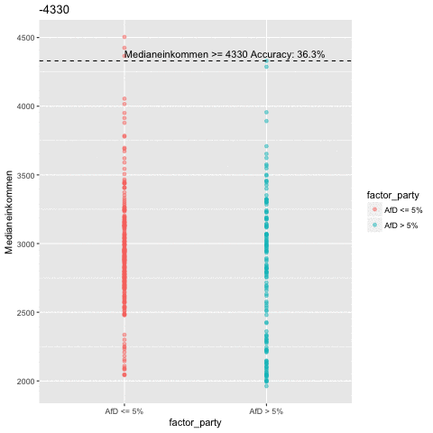

```r
accuracy = d %>%
  rowwise() %>%
  do(accuracy=sum((.$Medianeinkommen>=d$Medianeinkommen)==(d$factor_party=="AfD > 5%"))/nrow(d)) %>%
  ungroup() %>% .$accuracy %>% unlist
frames = d %>%
  mutate(accuracy = percent(accuracy)) %>% sample_n(30)
animation = d %>%
  ggplot() +
  geom_point(aes(factor_party, Medianeinkommen, color=factor_party), alpha = 0.5) +
  geom_hline(aes(yintercept = Medianeinkommen, frame=-Medianeinkommen), linetype = 2, data = frames) +
  geom_text(aes(y = Medianeinkommen, label=paste("Medianeinkommen >=", Medianeinkommen, "Accuracy:", accuracy), frame=-Medianeinkommen), x = 1, hjust = 0, vjust = -.5, data = frames)
gganimate(animation, interval = .5)
```

Nun haben wir einen sehr einfachen Entscheidungsbaum mit nur einer Gabelung und zwei Blättern. Wie macht man nun weiter?

### Rekursive Aufteilung der Trainingsdaten

In jedem Blatt befindet sich nun ein Teil der Trainingsdaten. Auf diesem Teil kann man genau dasselbe Verfahren nun wiederholen. Z.B. auf dem Teil mit Medianeinkommen < 2452 könnten wir die Wahlbeteiligung betrachten und wieder (nach demselben Prinzip wie vorher) einen Wert festlegen an dem ein Split stattfinden soll.

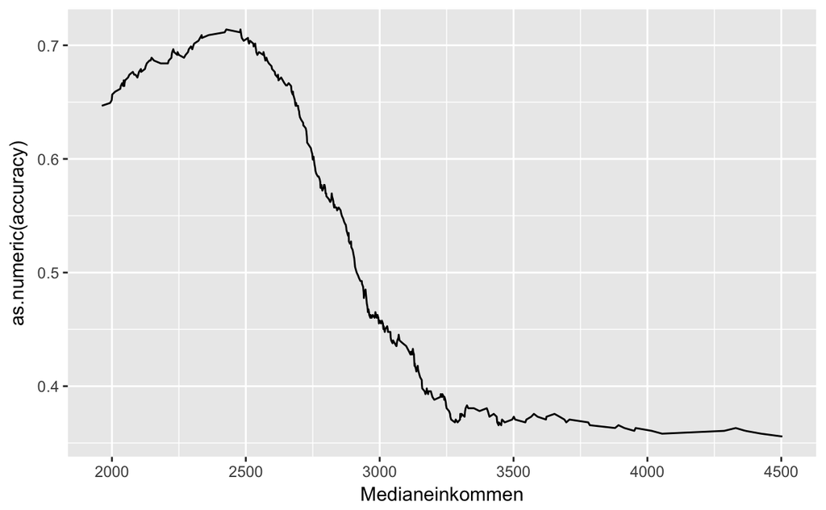

```r
d %>%
  mutate(accuracy = accuracy) %>%
  arrange(Medianeinkommen) %>%
  ggplot() +
  geom_line(aes(Medianeinkommen, as.numeric(accuracy)))
```

Auf diese Weise wir der “Merkmalsraum” in immer feinere Würfel eingeteilt, die immer “reiner” sind, d.h. sie enthalten größtenteils Datenpunkte einer einzigen Klasse.

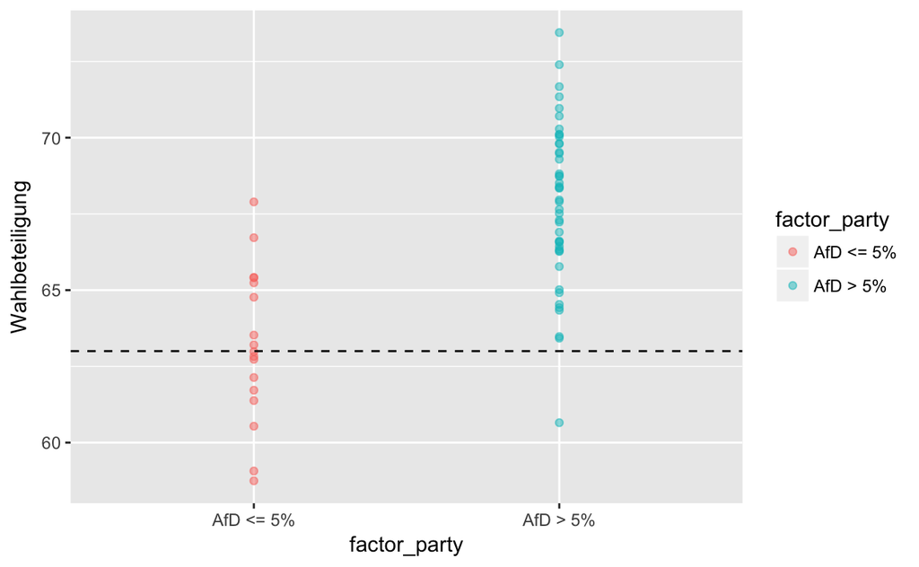

```r
d %>% filter(Medianeinkommen < 2452) %>%
  ggplot() +
  geom_point(aes(factor_party, Wahlbeteiligung, color=factor_party), alpha = 0.5) +
  geom_hline(yintercept = 63, linetype = 2)
```

## Model Building

Nun wollen wir das Modell trainieren. Dafür wählen wir als erstes die Merkmale aus, die wir als Prädiktoren verwenden wollen. Dies können wir in Form einer [R-Formel](https://stat.ethz.ch/R-manual/R-devel/library/stats/html/formula.html) tun bei der auf der linken Seite die Zielvariable steht und getrennt durch ein `~` auf der Rechten Seite die Prädiktoren.

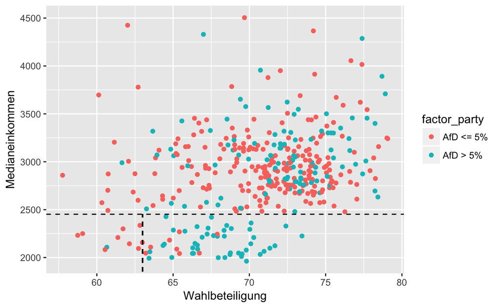

```r
d %>% ggplot() +
  geom_point(aes(Wahlbeteiligung, Medianeinkommen, color=factor_party)) +
  geom_hline(yintercept = 2452, linetype = 2) +
  geom_segment(x=63, xend=63, y = 0, yend = 2452, linetype = 2)
```

Das eigentliche Training findet mit der `train`-Methode aus `caret` statt. Wir initalisieren vorher den Zufallszahlengenerator mittels `set.seed` um reproduzierbare Ergebnisse zu bekommen. Wer legen außerdem Crossvalidation als Evaluationsmethode fest und geben die Anzahl der Hyperparameterkombinationen an, die wir probieren wollen. Hyperparameter sind Modellparameter, die bei Bäumen z.B. festlegen, wie tief der Baum maximal werden darf.

```r
variables <- factor_party ~ Wahlbeteiligung + Medianeinkommen + Arbeitslosenquote + Ausländeranteil + Mietpreis
# variables <- factor_party ~ Wahlbeteiligung + ost_west + Medianeinkommen + Arbeitslosenquote + Ausländeranteil + Mietpreis
# variables <- factor_party ~ .
d_clean <- na.omit(d) # NA-Werte löschen
```

Wenn wir uns das trainierte Modell ausgeben lassen, können wir sehen welche Genauigkeit für welchen Wert des Komplexitätsparameters cp (bestimmt, wie tief der Baum werden kann) erreicht wird.

```r
set.seed(123)
tc <- trainControl(method = "cv", number = 10) # Daten zufällig in zehn ähnlich große Blöcke aufteilen
train.rpart <- train(variables, data=d_clean, method="rpart", tuneLength=10, metric="Accuracy", trControl=tc) # Metric "Accuracy" für Classification, "Rsquared" für Regression
```

Wir können uns außerdem den Baum ausgeben lassen:

```r
train.rpart
```

```
CART

402 samples
  5 predictor
  2 classes: 'AfD <= 5%', 'AfD > 5%'

No pre-processing
Resampling: Cross-Validated (10 fold)
Summary of sample sizes: 361, 362, 362, 362, 362, 362, ...
Resampling results across tuning parameters:

  cp          Accuracy   Kappa
  0.00000000  0.6840854  0.29749582
  0.02175602  0.7264024  0.37227832
  0.04351204  0.7414024  0.39731218
  0.06526807  0.6940244  0.25899562
  0.08702409  0.7040244  0.26300769
  0.10878011  0.7115244  0.27769530
  0.13053613  0.7115244  0.27769530
  0.15229215  0.7115244  0.27769530
  0.17404817  0.7115244  0.27769530
  0.19580420  0.6468293  0.05372161

Accuracy was used to select the optimal model using  the largest value.
The final value used for the model was cp = 0.04351204.
```

`caret` bietet bei Baummodellen außerdem eine Funktion, die Wichtigkeit der Merkmale für das Modell grafisch auszugeben:

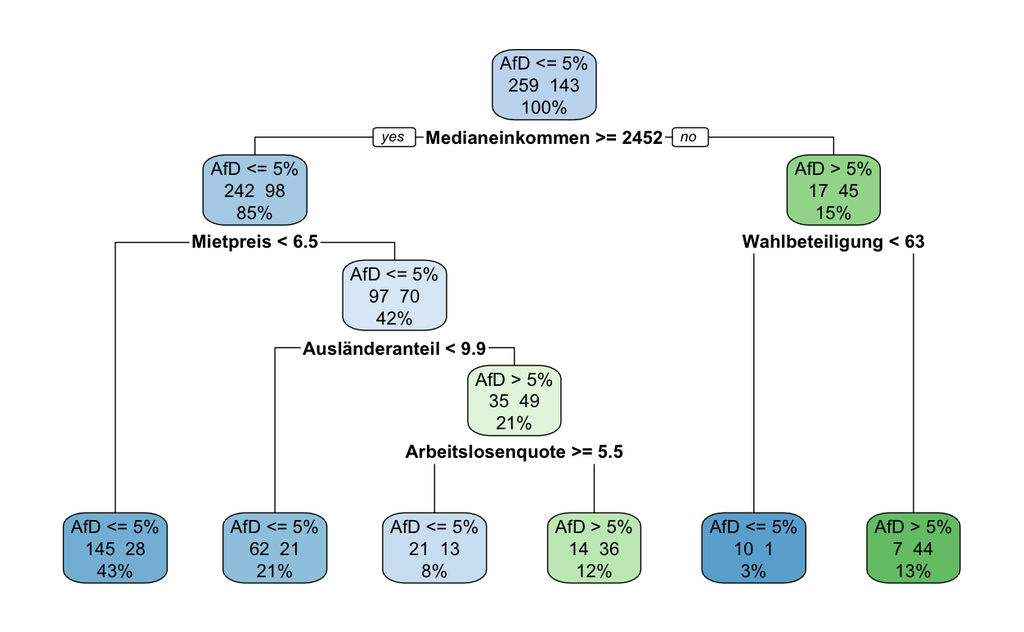

```r
rpart.plot(train.rpart$finalModel, extra=101)
```

## Andere Modelle

Wir haben den Entscheidungsbaum zwar explizit ausgewählt, weil er interpretiertbar ist, wollen jedoch noch kurz zeigen, dass es mit `caret` sehr einfach ist, komplexere Modelle zu verwenden. Die Funktionsaufrufe sind fast identisch. Hier trainieren wir zusätzlich zu einem Entschedungsbaum ein Modell namens Gradient Boosting Machine. Dieses hat eine Vielzahl von Hyperparametern und ist nicht mehr so einfach darstellbar und interpretierbar wie ein einzelner Entscheidungsbaum. Eine Liste der in Caret verfügbaren Modelle findet sich unter https://topepo.github.io/caret/available-models.html.

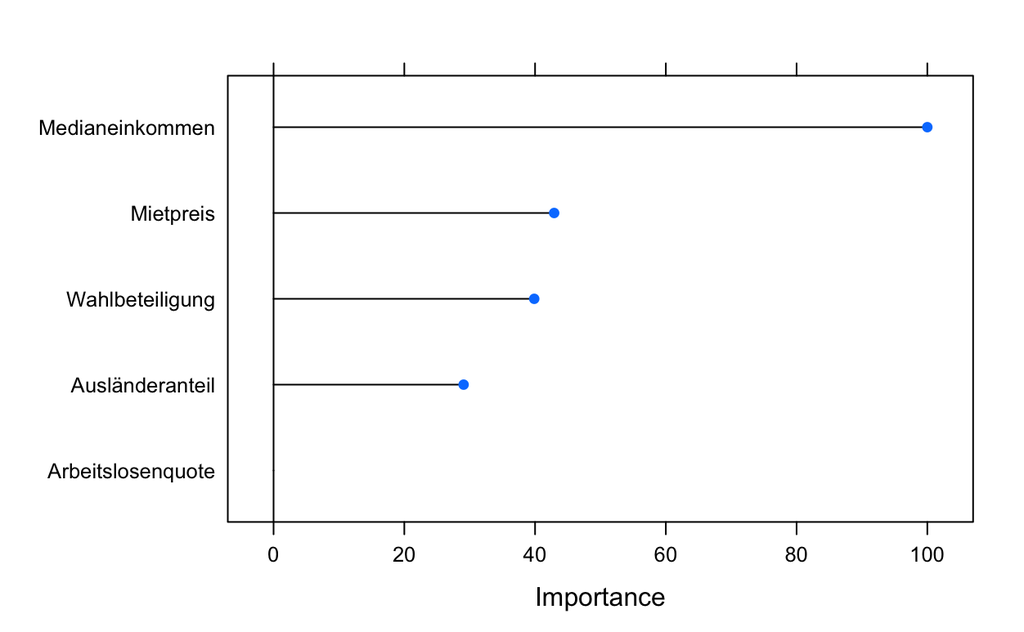

```r
plot(varImp(train.rpart, competes=F))
```

Die Genauigkeit dieses Modells ist tatsächlich etwas besser, als die eines Entscheidungsbauems.

```r
variables <- factor_party ~ .
set.seed(123)
train.rpart <- train(variables, data=d_clean, method="rpart", tuneLength=10, metric="Accuracy", trControl=tc)
train.gbm <- train(variables, data=d_clean, method="gbm", tuneLength=5, metric="Accuracy", trControl=tc, verbose=F)
# train.rf <- train(variables, data=d_clean, method="rf", tuneLength=5, metric="Accuracy", trControl=tc, verbose=F)
```

```r
summary(resamples(list(CART=train.rpart, gbm=train.gbm)))
```

```
Call:
summary.resamples(object = resamples(list(CART = train.rpart, gbm = train.gbm)))

Models: CART, gbm
Number of resamples: 10

Accuracy
          Min. 1st Qu.    Median      Mean 3rd Qu.  Max. NA's
CART 0.6829268  0.7500 0.7655488 0.7764024 0.81875 0.875    0
gbm  0.6585366  0.7375 0.8024390 0.7838415 0.82500 0.875    0

Kappa
          Min.   1st Qu.    Median      Mean   3rd Qu.      Max. NA's
CART 0.2405063 0.4029314 0.4467421 0.4699941 0.5679817 0.7206704    0
gbm  0.2427441 0.3955783 0.5430354 0.5035763 0.5935906 0.7005988    0
```